# Lab 7: Practicing `dplyr` Verbs and Base Plotting

Before proceeding to the formal exercise, make sure the `tidyverse` collection is installed in your lab computer.

```r
library(tidyverse)
```

Sociological studies of the diffusion of innovations focus on identifying “early adopters” and examine how innovations “spread”" from them to others. In this lab, we will look at a dataset that tracks how an antibiotic named tetracycline spread among doctors in Illionis in the 50s. The ckm_nodes.csv file contains information about each individual doctor.

Load the dataset to create a tibble named ckm_nodes using `read_csv()` from the `readr` package:

```r
ckm_nodes <- read_csv("https://drive.google.com/uc?export=download&id=12r_nJJKXNT_AynQ3EsktTsE-YTOrQmZO",
    col_names = TRUE)
ckm_nodes
```

```
## # A tibble: 246 x 13
##    city  adoption_date medical_school attend_meetings medical_journals
##    <chr>         <dbl> <chr>          <chr>                      <int>
##  1 Peor~             1 1920--1929     specialty                      9
##  2 Peor~            12 1945+          none                           5
##  3 Peor~             8 1935--1939     general                        7
##  4 Peor~             9 1940--1944     general                        6
##  5 Peor~             9 1935--1939     general                        4
##  6 Peor~            10 1930--1934     none                           7
##  7 Peor~           Inf 1919-          none                           3
##  8 Peor~             3 1935--1939     none                           9
##  9 Peor~            11 1920--1929     specialty                      5
## 10 Peor~             2 1935--1939     general                        4
## # ... with 236 more rows, and 8 more variables: free_time_with <chr>,
## #   discuss_medicine_socially <chr>, club_with_drs <chr>,
## #   drs_among_three_best_friends <int>, practicing_here <chr>,
## #   office_visits_per_week <chr>, proximity_to_other_drs <chr>,
## #   specialty <chr>
```

Check that it has 246 rows and 13 columns.

```r
dim(ckm_nodes)
```

```
## [1] 246  13
```

adoption_date records the month in which the doctor began prescribing the antibiotic counting from a fixed point in time. If the doctor did not begin prescribing it by month 17, this is recorded as `Inf`. If it’s not known when or if a doctor adopted the then-new antibiotic, the value is `NA`.

1. How many doctors began prescribing the antibiotic in each month of the study? How many never prescribed? How many are `NA`s? Hint: `table()` in base R or `group_by()`, `summarise()` and `n()` in the `dplyr` package.

```r
# Edit your code here

table(ckm_nodes$adoption_date, useNA = c("ifany"))
```

```
##
##    1    2    3    4    5    6    7    8    9   10   11   12   13   14   15
##   11    9    9   11   11   11   13    7    4    1    5    3    3    4    4
##   16   17  Inf <NA>
##    2    1   16  121
```

2. Subset doctors for whom adoption_date is not `NA`. Re-assign this subset to ckm_nodes so it only contains those rows. Check that this vector has length 125. Use this cleaned version of `ckm_nodes` for the rest of the exercise. Hint: `filter()` in `dplyr`.

```r
# Edit your code here


ckm_nodes = filter(ckm_nodes, !is.na(adoption_date))



dim(ckm_nodes)
```

```
## [1] 125  13
```

3. Create plots of the number of doctors who began prescribing tetracycline each month versus time. (It is OK for the numbers on the horizontal axis to just be integers rather than formatted dates.)

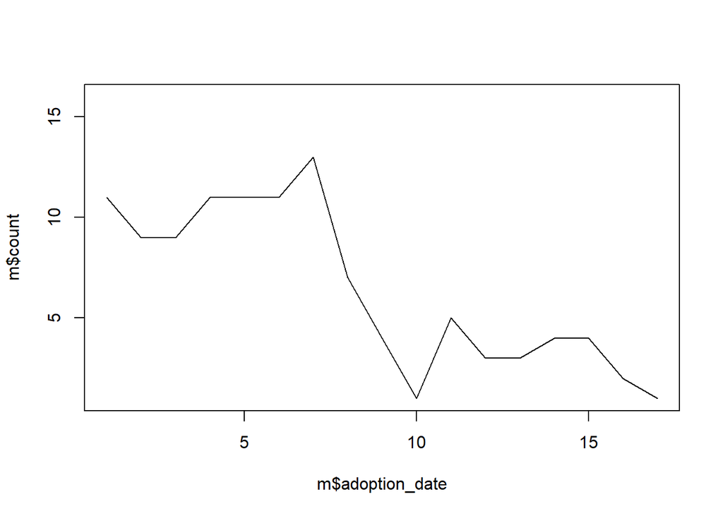

```r
# Edit your code here

m = group_by(ckm_nodes, adoption_date)

m = summarise(m, count = n())
plot(m$adoption_date, m$count, type = "l")
```

4. Produce a plot of the total number of adopters in each month. The curve for total adoptions should first rise rapidly and then level out around month 6. Hint: `mutate()` and `cumsum()`.

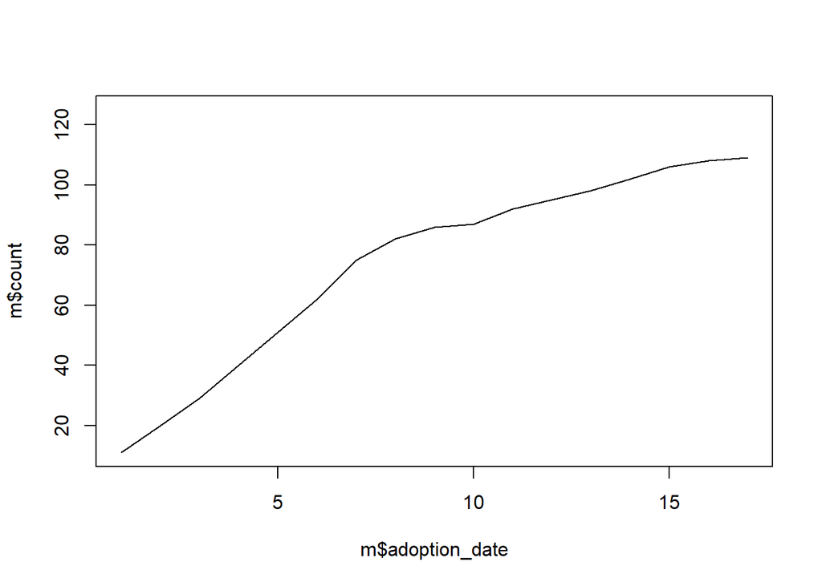

```r
# Edit your code here

m$count <- cumsum(m$count)
plot(m$adoption_date, m$count, type = "l")
```